# Spatially Balanced Sampling

Michael Dumelle, Tom Kincaid, Anthony Olsen, and Marc Weber

If you have yet not read the “Start Here” vignette, please do so by running

```r
vignette("start-here", "spsurvey")
```

# 1 Introduction

The Generalized Random Tessellation Stratified (GRTS) algorithm (Stevens and Olsen, 2004, Olsen et.al., 2012) is a spatially balanced sampling algorithm available in spsurvey. The GRTS algorithm is used to sample from finite populations (point resources – e.g. lakes treated as a whole) and infinite populations (linear resources – e.g. rivers and streams; areal resources – e.g. wetlands and coastlines) and is implemented in spsurvey using the `grts()` function. The output from `grts()` contains the design sites and additional information about the sampling design. More specifically, it is a list with five elements:

1. `sites_legacy`: legacy sites included in the base (main) sample (see Legacy sampling)
2. `sites_base`: sites included in the base (main) sample that are not legacy sites
3. `sites_over`: replacement sites obtained using reverse hierarchical ordering (see Reverse hierarchical ordering)
4. `sites_near`: replacement sites obtained using nearest neighbor (see Nearest neighbor)
5. `design`: a list detailing the sampling design

We use the `NE_Lakes` sampling frame in spsurvey to introduce spatially balanced sampling via the GRTS algorithm. `NE_Lakes` is a finite sampling frame and contains lakes (treated as a whole) from the Northeastern United States. There are a few variables in `NE_Lakes` you will throughout this vignette:

1. `AREA`: lake area in hectares
2. `AREA_CAT`: lake area categories (small and large)
3. `ELEV_CAT`: lake elevation categories (low and high)

Before proceeding, we load spsurvey and set a reproducible seed by running

```r
library(spsurvey)
set.seed(51)
```

# 2 Unstratified sampling

## 2.1 Equal inclusion probabilities

To select an unstratified GRTS sample where each site in the sampling frame has an equal probability of selection (i.e. inclusion probability), run

```r
eqprob <- grts(NE_Lakes, n_base = 50)
```

The first argument to `grts()` is the sampling frame, which must be an `sf` object. The second argument is `n_base`, which specifies the number of sites in the base (main) sample. The `sites_base` object in `eqprob` is an `sf` object and contains the original columns of `NE_Lakes` as well as a few additional columns such as a site identifier, latitude and longitude coordinates, inclusion probabilities, and design weights (to be used in analyses after collecting data).

To print a summary of site counts, run

```r
eqprob
```

```
#> Summary of Site Counts:
#>
#>    total    siteuse
#>  total:50   Base:50
```

To visualize the design sites overlain onto the sampling frame, run

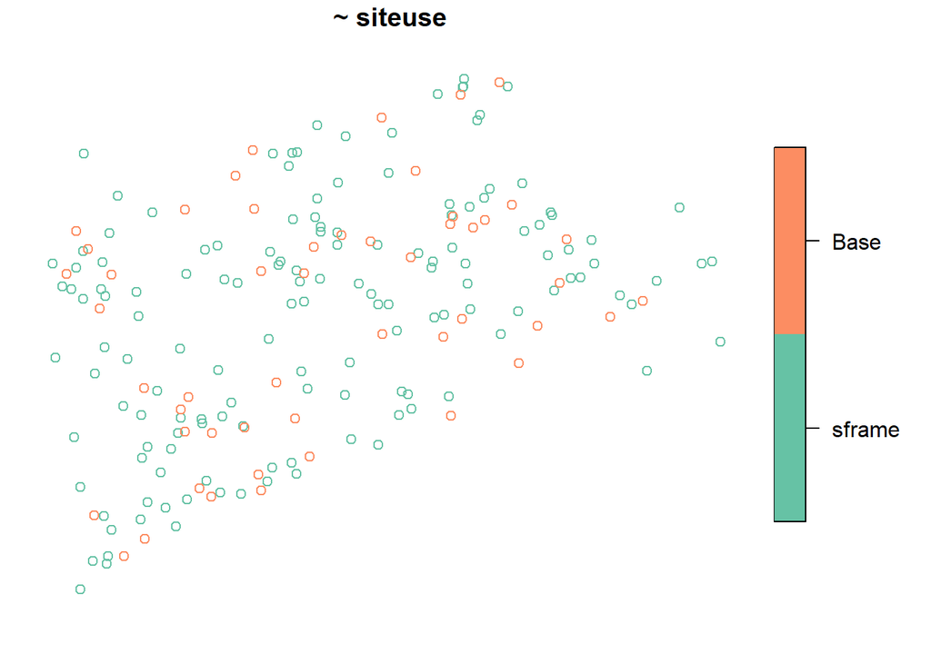

```r
plot(eqprob, NE_Lakes, key.width = lcm(3))
```

The `key.width` argument extends the plot’s margin to fit the legend text nicely within the plot. `sp_plot()` can equivalently be used in place of `plot()` (`sp_plot()` is currently maintained for backwards compatibility with previous spsurvey versions).

## 2.2 Unequal inclusion probabilities

To select an unstratified GRTS sample where each site in the sampling frame has unequal inclusion probabilities according to some categorical variable, run

```r
caty_n <- c(small = 40, large = 10)
uneqprob <- grts(
  NE_Lakes,
  n_base = 50,
  caty_var = "AREA_CAT",
  caty_n = caty_n
)
uneqprob
```

```
#> Summary of Site Counts:
#>
#> siteuse by total:
#>       Base
#> total   50
#>
#> siteuse by caty:
#>       Base
#> large   10
#> small   40
```

`caty_var` is the unequal inclusion probability variable (`"AREA_CAT"` in `NE_Lakes`), and `caty_n` is a vector whose names are the levels in `caty_var` and whose values are the expected sample sizes in each category (the sum of these expected samples sizes must equal `n_base`). In this sample, inclusion probabilities are adjusted so that on average, there are 40 small lakes and 10 large lakes selected.

## 2.3 Proportional inclusion probabilities

To select an unstratified GRTS sample where each site in the sampling frame has inclusion probability proportional to a positive, continuous variable, run

```r
propprob <- grts(
  NE_Lakes,
  n_base = 50,
  aux_var = "AREA"
)
```

`aux_var` is the proportional probability (auxiliary) variable (`"AREA"` in `NE_Lakes`). Proportional (to size) inclusion probabilities are useful because they can increase the precision of estimates when the response variable is positively correlated with the proportional probability variable.

# 3 Stratified sampling

Stratified sampling designs partition the sampling frame into distinct groups called strata and sites are selected within each stratum independently of other strata. Stratified sampling is useful from a practical perspective because it allows for stratum-specific sample sizes and implementation practices (e.g. each stratum may have different sampling protocols). Stratified sampling is useful from a statistical perspective because estimates from stratified samples tend to be more precise than estimates from unstratified samples.

## 3.1 Equal inclusion probabilities

To select a sample stratified by elevation category with equal inclusion probabilities in each stratum, run

```r
strata_n <- c(low = 25, high = 15)
strat_eqprob <- grts(NE_Lakes, n_base = strata_n, stratum_var = "ELEV_CAT")
strat_eqprob
```

```
#> Summary of Site Counts:
#>
#> siteuse by total:
#>       Base
#> total   40
#>
#> siteuse by stratum:
#>      Base
#> high   15
#> low    25
```

`strata_n` is a named vector whose names represent the strata and whose values represent strata-specific sample sizes, and `stratum_var` is the stratification variable (`ELEV_CAT` in `NE_Lakes`).

To visualize the design sites overlain onto the sampling frame (separately for each stratum), run

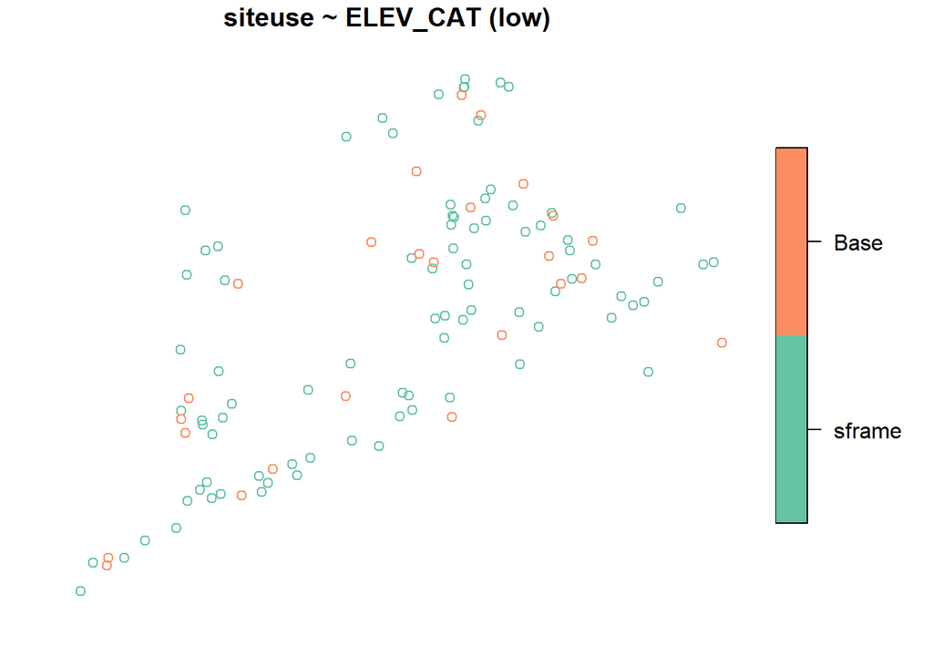

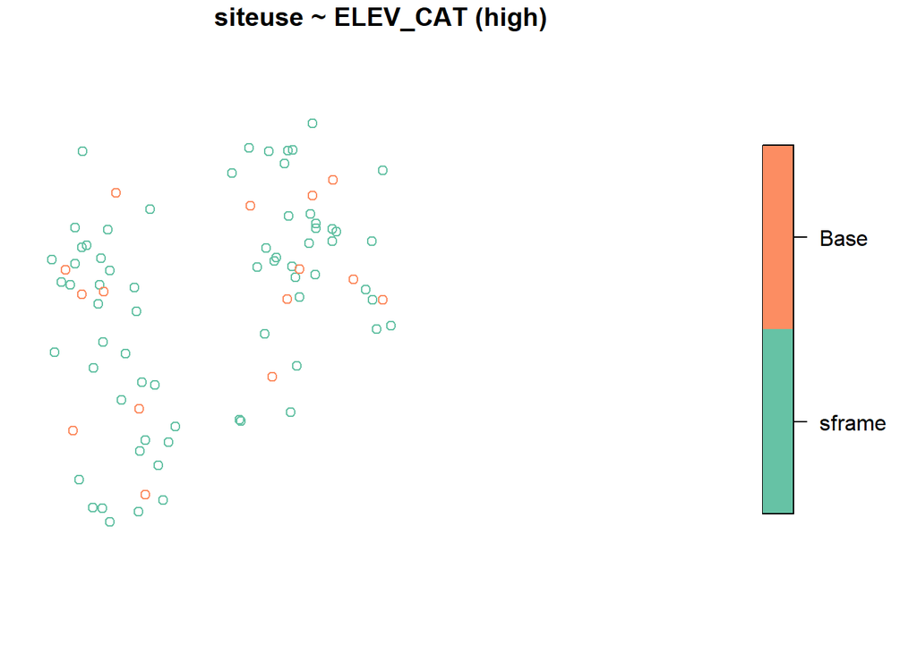

```r
plot(
  strat_eqprob,
  formula = siteuse ~ ELEV_CAT,
  NE_Lakes,
  key.width = lcm(3)
)
```

## 3.2 Unequal inclusion probabilities

To select a sample stratified by elevation category with unequal inclusion probabilities for each area category, run

```r
caty_n <- list(
  low = c(small = 20, large = 5),
  high = c(small = 10, large = 5)
)
strat_uneqprob <- grts(
  NE_Lakes,
  n_base = strata_n,
  stratum_var = "ELEV_CAT",
  caty_var = "AREA_CAT",
  caty_n = caty_n
)
strat_uneqprob
```

```
#> Summary of Site Counts:
#>
#> siteuse by total:
#>       Base
#> total   40
#>
#> siteuse by stratum:
#>      Base
#> high   15
#> low    25
#>
#> siteuse by caty:
#>       Base
#> large    9
#> small   31
#>
#> siteuse by stratum:caty:
#>            Base
#> high:large    3
#> low:large     6
#> high:small   12
#> low:small    19
```

`caty_n` is now a list: the first element contains the expected sample sizes for each area category in the low elevation stratum, and the second element contains the expected sample sizes for each area category in the high elevation stratum.

## 3.3 Proportional inclusion probabilities

To select a sample stratified by elevation category with probabilities proportional to lake area, run

```r
strat_propprob <- grts(
  NE_Lakes,
  n_base = strata_n,
  stratum_var = "ELEV_CAT",
  aux_var = "AREA"
)
```

# 4 Additional sampling options

## 4.1 Legacy sampling

Legacy (historical) sites are sites that were selected from a previous sampling design that incorporated randomness into site selection, are part of the sampling frame for the current sampling design, and should be always be selected in the current sample. The `NE_Lakes_Legacy` data contains some legacy sites. To accommodate these legacy sites while sampling, use the `legacy_sites` argument:

```r
legacy <- grts(NE_Lakes, n_base = 50, legacy_sites = NE_Lakes_Legacy)
legacy
```

```
#> Summary of Site Counts:
#>
#>    total      siteuse
#>  total:50   Legacy: 5
#>             Base  :45
```

To visualize the legacy and base sites together, run

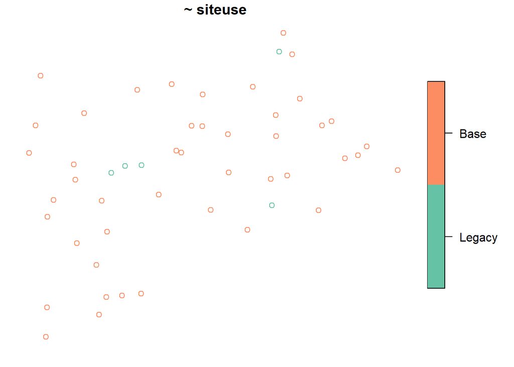

```r
plot(legacy, key.width = lcm(3))
```

These points can be overlain onto the sampling frame by including `NE_Lakes` in the `plot()` command.

Legacy sites are included in the base (main) sample, so the value for `n_base` should be equal to the number of legacy sites plus the number of non-legacy sites desired in the sample. If your sampling design uses stratification, unequal inclusion probabilities, or proportional inclusion probabilities, you need to name the column in `legacy_sites` that represents these values. By default, `grts()` assumes that the respective columns in `sframe` and `legacy_sites` share the same name – if this is not the case, use the `legacy_stratum_var`, `legacy_caty_var` or `legacy_aux_var` arguments. If your population is finite, you may alternatively accommodate legacy sites by including a variable in your sampling frame that indicates whether each site is a legacy site or not and then use the `legacy_var` argument in `grts()`. When using `legacy_var`, you do not need to use `legacy_stratum_var`, `legacy_caty_var` or `legacy_aux_var`.

Another legacy site example is provided in Infinite Population Sampling.

## 4.2 Minimum distance sampling

Though the GRTS algorithm selects spatially balanced samples, the algorithm can select sites that are closer together than you may desire. To enforce a minimum distance between sites, run

```r
mindis <- grts(NE_Lakes, n_base = 50, mindis = 1600)
```

Here we have specified that sites be no closer together than 1600 meters (meters are the units of the `sf` object). In some situations, the `grts()` function will fail to enforce the minimum distance requirement for all sites. When this occurs, the function will enforce the requirement for as many sites as possible and then return a warning.

When stratifying, `mindis` will apply to all strata if it is a single value. It is possible to set stratum-specific minimum distance requirements by storing them in a named list (the names must match the strata):

```r
mindis_list <- list(low = 1400, high = 1000)
strat_mindis <- grts(
  NE_Lakes,
  strata_n,
  stratum_var = "ELEV_CAT",
  mindis = mindis_list
)
```

## 4.3 Replacement sampling

Sometimes data cannot be collected at a site. This may occur for a variety of reasons, some of which include landowner denial or inaccessible sites. The `grts()` function has two options for selecting replacement sites, which are sites available to replace sites in the base (main) sample for which data cannot be collected.

### 4.3.1 Reverse hierarchical ordering

The first replacement site option is reverse hierarchical ordering (Stevens and Olsen, 2004). To select a base sample with reverse hierarchically ordered replacement sites, run

```r
rho_replace <- grts(NE_Lakes, n_base = 50, n_over = 25)
rho_replace
```

```
#> Summary of Site Counts:
#>
#>    total    siteuse
#>  total:75   Base:50
#>             Over:25
```

`n_base` indicates the desired sample size, and `n_over` indicates the number of replacement sites. Sites are first selected using the GRTS algorithm for a sample size of `n_base + n_over`. They are then determined as base sites or replacement sites in a way that preserves as much spatial balance as possible. The spatial balance of the base sites degrades as `n_over` increases, however, so it is important to choose a realistic value for `n_over`.

To visualize the base sites and reverse hierarchically ordered replacement sites, run

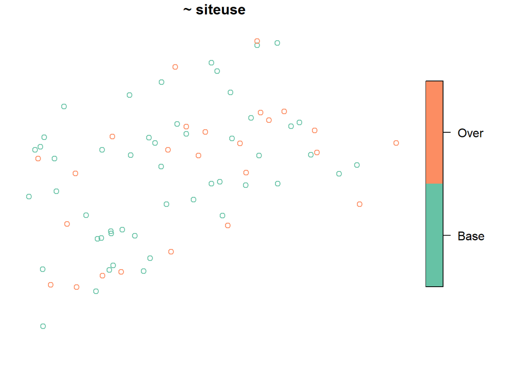

```r
plot(rho_replace, key.width = lcm(3))
```

When stratifying, `n_over` will apply to all strata if it is a single value. It is possible to set stratum-specific reverse hierarchical ordering requirements by storing them in a named list (the names must match the strata):

```r
over_list <- list(low = 2, high = 5)
strat_rho_replace <- grts(
  NE_Lakes,
  strata_n,
  stratum_var = "ELEV_CAT",
  n_over = over_list
)
strat_rho_replace
```

```
#> Summary of Site Counts:
#>
#> siteuse by total:
#>       Base Over
#> total   40    7
#>
#> siteuse by stratum:
#>      Base Over
#> high   15    5
#> low    25    2
```

### 4.3.2 Nearest neighbor

The second replacement site option is nearest neighbor. To select a base sample with nearest neighbor replacement sites, run

```r
nn_replace <- grts(NE_Lakes, n_base = 50, n_near = 1)
nn_replace
```

```
#> Summary of Site Counts:
#>
#>    total     siteuse
#>  total:100   Base:50
#>              Near:50
```

`n_base` indicates the desired sample size, and `n_near` indicates the number of replacement sites for each base site. For `n_near = 1`, each site in the base sample has a replacement site associated with it – this replacement site is the closest site (measured by Euclidean distance) to the base site (within a stratum).

When stratifying, `n_near` will apply to all strata if it is a single value. It is possible to set stratum-specific nearest neighbor requirements by storing them in a named list (the names must match the strata):

```r
near_list <- list(low = 1, high = 2)
strat_nn_replace <- grts(
  NE_Lakes,
  strata_n,
  stratum_var = "ELEV_CAT",
  n_near = near_list
)
strat_nn_replace
```

```
#> Summary of Site Counts:
#>
#> siteuse by total:
#>       Base Near
#> total   40   55
#>
#> siteuse by stratum:
#>      Base Near
#> high   15   30
#> low    25   25
```

## 4.4 Independent Random Sampling

If you want to select samples that are not spatially balanced, use spsurvey’s `irs()` function (IRS is for Independent Random Sampling). The function arguments for the `irs()` function are the same as the function arguments for the `grts()` function. This means that the flexible sampling design options available for the GRTS algorithm are also available for the IRS algorithm. To select an unstratified IRS sample where each site in the sampling frame has an equal inclusion probability, run

```r
eqprob_irs <- irs(NE_Lakes, n_base = 50)
eqprob_irs
```

```
#> Summary of Site Counts:
#>
#>    total    siteuse
#>  total:50   Base:50
```

To visualize the design sites, run

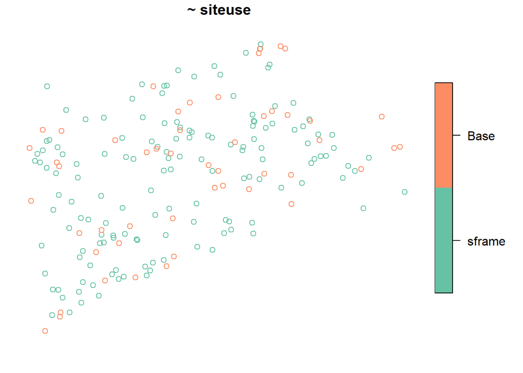

```r
plot(eqprob_irs, NE_Lakes, key.width = lcm(3))
```

Notice how these IRS design sites appear less spread out than the design sites from the unstratified GRTS sample with equal inclusion probabilities.

To select an IRS sample stratified by elevation category with equal inclusion probabilities in each stratum, run

```r
strata_n <- c(low = 25, high = 15)
strat_eqprob_irs <- irs(NE_Lakes, n_base = strata_n, stratum_var = "ELEV_CAT")
strat_eqprob_irs
```

```
#> Summary of Site Counts:
#>
#> siteuse by total:
#>       Base
#> total   40
#>
#> siteuse by stratum:
#>      Base
#> high   15
#> low    25
```

# 5 Measuring spatial balance

So far we have talked generally about spatial balance but not about how to measure it. Stevens and Olsen (2004) proposed measuring spatial balance using Voronoi polygons. A design site’s Voronoi polygon contains all sites in the sampling frame closer to this design site than any other design site. To measure spatial balance, these Voronoi polygons are combined with the inclusion probabilities of all sites in the sampling frame and a loss metric.

Several spatial balance metrics are available in spsurvey. The default is Pielou’s evenness index. Pielou’s evenness index ranges from 0 (perfect spatial balance) to 1 (a complete lack of spatial balance). Larger values of the Pielou’s evenness index indicate worse spatial balance. To measure the spatial balance of the unstratified GRTS and IRS samples with equal inclusion probabilities, run

```r
sp_balance(eqprob$sites_base, NE_Lakes) # grts
```

```
#>   stratum metric      value
#> 1    None pielou 0.02585831
```

```r
sp_balance(eqprob_irs$sites_base, NE_Lakes) # irs
```

```
#>   stratum metric      value
#> 1    None pielou 0.03823327
```

The GRTS design sites are more spatially balanced than the IRS design sites.

In a stratified sample, spatial balance is calculated separately for each stratum:

```r
sp_balance(strat_eqprob$sites_base, NE_Lakes, stratum_var = "ELEV_CAT") # grts
```

```
#>   stratum metric      value
#> 1     low pielou 0.03680620
#> 2    high pielou 0.04543609
```

```r
sp_balance(strat_eqprob_irs$sites_base, NE_Lakes, stratum_var = "ELEV_CAT") # irs
```

```
#>   stratum metric     value
#> 1     low pielou 0.0415444
#> 2    high pielou 0.1171086
```

The GRTS design sites are more spatially balanced than the IRS design sites in both strata.

# 6 Infinite population sampling

Though this vignette used a finite population (`NE_Lakes`) to illustrate the sampling options available in spsurvey, the same commands are used to sample from infinite populations. The `Illinois_River` `sf` object in spsurvey is a linear resource and the `Lake_Ontario` `sf` object in spsurvey is an areal resource – both are examples of infinite populations. To select a GRTS sample with equal inclusion probabilities from `Illinois_River`, run

```r
eqprob <- grts(Illinois_River, n_base = 50)
```

To visualize the design sites overlain onto the sampling frame, run

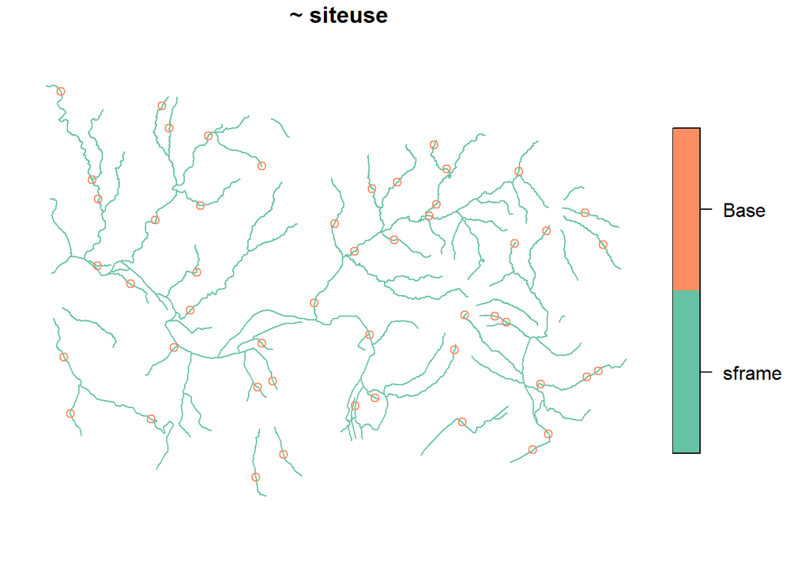

```r
plot(eqprob, Illinois_River, key.width = lcm(3))
```

To accommodate the Illinois River legacy sites, run:

```r
legacy <- grts(Illinois_River, n_base = 50, legacy_sites = Illinois_River_Legacy)
```

To select a GRTS sample with equal inclusion probabilities from `Lake_Ontario`, run

```r
eqprob <- grts(Lake_Ontario, n_base = 50)
```

To visualize the design sites (with closed circles) overlain onto the sampling frame, run

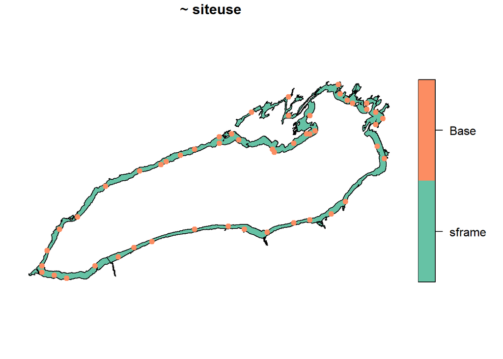

```r
plot(eqprob, Lake_Ontario, pch = 19, key.width = lcm(3))
```

# 7 Binding design sites

To bind `sites_legacy`, `sites_base`, `sites_over`, `sites_near` (four separate `sf` objects) into a single `sf` object, use `sp_rbind()`. For example, to combine the base and reverse hierarchically ordered replacement sites from `rho_replace` into a single `sf` object, run

```r
combined <- sp_rbind(rho_replace)
```

Then it is straightforward to write out a single `sf` object using a function like `sf::write_sf()`. For example, to save the combined `sf` object as a shapefile named `"file_name.shp"` at the location on your machine called `"file_path"`, run

```r
write_sf(combined, "file_path/file_name.shp")
```

# 8 References

Olsen, A. R., T. M. Kincaid and Q. Payton (2012). Spatially balanced survey designs for natural resources. Design and Analysis of Long-Term Ecological Monitoring Studies. R. A. Gitzen, J. J. Millspaugh, A. B. Cooper and D. S. Licht. Cambridge, UK, Cambridge University Press: 126-150.

Stevens Jr, D. L. and Olsen, A. R. (2004). Spatially balanced sampling of natural resources. *Journal of the American Statistical Association*, 99(465):262-278.